# R Notebook

Annotate the full 9MBO dataset 1. Use Random Forest Model (RFM) - train model from Annotated hMO subset 2. Correlation assignment model (CAM) - run correlation 3. Use Seurat label transfer - transfer labels from annotated hMO subset

For each prediction method visualize on UMAP and get frequency of cell type predictions per cluster (bar chart and df)

````r
```r
# load libraries
````

````r
```r
```r
library(Seurat)
````

````r
```r
```r
library(dplyr)
````

Attaching package: ‘dplyr’

The following objects are masked from ‘package:stats’:

```r
filter, lag
```

The following objects are masked from ‘package:base’:

```r
intersect, setdiff, setequal, union
```

````r
```r
```r
library(ggplot2)
library(reshape2)
library(randomForest)
````

Attaching package: ‘randomForest’

The following object is masked from ‘package:ggplot2’:

```r
margin
```

The following object is masked from ‘package:dplyr’:

```r
combine
```

````r
```r
```r
library(scProportionTest)
````

````r
```r
```r

# output path for data objects
outpath <- \/Users/rhalenathomas/Documents/Data/FlowCytometry/PhenoID/Analysis/PaperFigures/\
# output path for figures
output_path <- \/Users/rhalenathomas/Documents/Projects_Papers/PhenoID/ForFigures/\
# read in files needed:
# data object with clustering done ready to label
seu.q <- readRDS(\/Users/rhalenathomas/Documents/Data/FlowCytometry/PhenoID/Analysis/9MBO/prepro_outs/clusters/Louvain/Allcellsretros_LouvainSeuratObject60.Rds\)
# reference hMO subset annotated
seu.r<- readRDS(\/Users/rhalenathomas/Documents/Data/FlowCytometry/PhenoID/Analysis/PaperFigures/Seu9000annot.08072021.RDS\)

# antibody features in order
AB <- c(\CD24\,\CD56\,\CD29\,\CD15\,\CD184\,\CD133\,\CD71\,\CD44\,\GLAST\,\AQP4\,\HepaCAM\, \CD140a\,\O4\)


seu <- readRDS(paste(outpath,\seuAllcells.15072022.Rds\))
````

```
Rasterizing points since number of points exceeds 100,000.
To disable this behavior set `raster=FALSE`
```

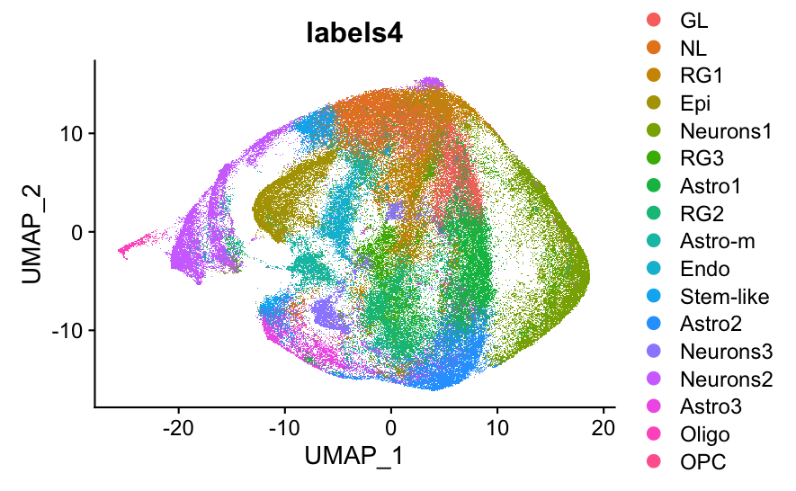

````r
```r
DimPlot(seu.q, raster = TRUE, group.by = "labels4")
````

```r
#DimPlot(seu.r)
```

Temp: remove excess metadata

```r
colnames(seu.q@meta.data)
```

```
 [1] "orig.ident"                         "nCount_RNA"
 [3] "nFeature_RNA"                       "Batch"
 [5] "RNA_snn_res.0.1"                    "seurat_clusters"
 [7] "RNA_snn_res.0.25"                   "RNA_snn_res.0.5"
 [9] "RNA_snn_res.1"                      "RNA_snn_res.1.5"
[11] "rf.pred"                            "cor.labels"
[13] "predicted.id"                       "prediction.score.Astrocytes.2"
[15] "prediction.score.Oligodendrocytes"  "prediction.score.Endothelial"
[17] "prediction.score.Neural.stem"       "prediction.score.Neurons.2"
[19] "prediction.score.NPC"               "prediction.score.Epithelial"
[21] "prediction.score.Radial.Glia.2"     "prediction.score.Radial.Glia.1"
[23] "prediction.score.Neurons.3"         "prediction.score.Astrocytes.mature"
[25] "prediction.score.Unknown"           "prediction.score.Neurons.1"
[27] "prediction.score.Astrocytes.3"      "prediction.score.Mixed"
[29] "prediction.score.Radial.Glia.3"     "prediction.score.Stem.like.1"
[31] "prediction.score.Astrocytes.1"      "prediction.score.Stem.like.2"
[33] "prediction.score.max"               "labels1"
[35] "labels2"                            "labels3"
[37] "labels.main"                        "labels4"
[39] "cell.types"                         "Genotype"
[41] "Ex.date"                            "mo.batch"
[43] "age"                                "m.gene"
[45] "ipsc"                               "most.subgroups"
[47] "subgroups"                          "gating.groups1"
```

```r
seurat_obj <- seu.q
# Define the metadata columns you want to keep
metadata_to_keep <- c("orig.ident","nCount_RNA","nFeature_RNA","Batch",
                      "age","ipsc", "gating.groups1","Ex.date","RNA_snn_res.0.25",
                      "RNA_snn_res.0.5",
                      "RNA_snn_res.1",
                      "labels.main","labels4")

# Update the Seurat object to keep only the desired metadata columns
seurat_obj@meta.data <- seurat_obj@meta.data[, metadata_to_keep]
colnames(seurat_obj@meta.data)
```

```
 [1] "orig.ident"       "nCount_RNA"       "nFeature_RNA"
 [4] "Batch"            "age"              "ipsc"
 [7] "gating.groups1"   "Ex.date"          "RNA_snn_res.0.25"
[10] "RNA_snn_res.0.5"  "RNA_snn_res.1"    "labels.main"
[13] "labels4"
```

Random Forest Classifier

````r
```r
```r

# A function will be made for training the model and running it.
# For now I'm going to run the training and run the predictions with the new model
# see the file: 'RandomForest.Fig4.July10.R'

# read in the saved model
rf <- readRDS(\/Users/rhalenathomas/Documents/Data/FlowCytometry/PhenoID/Analysis/PaperFigures/RFM_trained.11072022.Rds\)

# run the model to predict cell types in the unlabelled full hMO dataset
# need to prepare the full dataset in a way to be read by RFM
df <- transpose(as.data.frame(GetAssayData(seu.q,slot = 'scale.data')))
dim(df)
colnames(df) <- AB
rfm.pred <- predict(rf,df)
head(rfm.pred)
results.df <- as.data.frame(rfm.pred)
head(results.df)

# save the results
write.csv(results.df, paste(outpath, \RFMpredictionsAllcells.12072022.csv\))

# add the predictions to the seurat object
seu.q <- AddMetaData(object=seu.q, metadata= as.factor(results.df$rfm.pred), col.name = 'rf.pred')
unique(seu.q$rf.pred)
# save the RFM predictions
saveRDS(seu.q, paste(outpath,\All9MOannaote.12072022.Rds\))
````

[output not shown]

````r
```r
anchors <- FindTransferAnchors(reference = seu.r, query = seu.q,features = AB ,reference.reduction = \pca\, dim= 1:10)
````